# Python and Tipsy

Danielle De La Paz

2020-05-13

# Python

Danielle De La Paz

5/13/2020

Hey Y’all! Welcome to my first Python Blog Post! Before I dive right in, I have to tell you about my doggo Tipsy! I got her as a present when I was studying for my DAT and we’ve been best friends ever since, she is a white fluffy Bishon Frise!!!

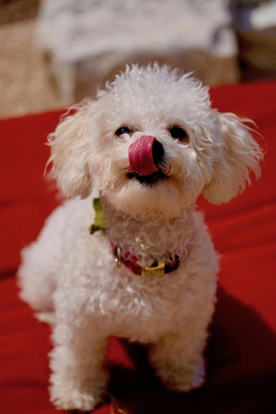

To start, in my SDS 348 class we have been learning about the interaction between R code and Python. I thought it would be neat to discuss how they interact with each other. To begin I included an R code chunk to show you how the two can work together!!

R code:

```r
library(reticulate)
Tipsy <- "Tipsy is a Future Dental"
```

Python code:

```python
Tipsy="Doggo"
print(r.Tipsy,Tipsy)
```

```
## Tipsy is a Future Dental Doggo
```

Hehehe as y’all know I aspire to become a Dentist so I thought it would only be appropriate to include my bestie in the code. This code begins with an R chunk followed by a python chunk, within the function “print” I was able to access the R defined object to make a complete sentence.

Another cool feature in Python is finding how many times a certain instance occcurs within a string. Below are a couple examples of how python can take a long string and find how many times something occurs.

The first thing were going to search for is exactly how many times does the word “dog” occur followed by anything.

```python
import re
x="dog doggy dogwalker dogggo odddog funnydog dogsgonewild wholetthedogsout"
re.findall(r"dog.",x)
```

```
## ['dog ', 'dogg', 'dogw', 'dogg', 'dog ', 'dog ', 'dogs', 'dogs']
```

This shows that there are 8 matches of the word “dog” followed by anything.

The next example were going to search for is exactly how many times the letter d appears followed by anything than the letter g occurs.

```python
re.findall(r"d.g",x)
```

```
## ['dog', 'dog', 'dog', 'dog', 'dog', 'dog', 'dog', 'dog']
```

This example also shows that there are 8 matches of the letter “d” followed by anything than the letter “g”.

Another cool python function is being able to filter a list with the function “regex”. In this example I will use a list with multiple strings and use filter to match the pattern I want from the list. This certain list is names I thought about naming tipsy before I got her. The pattern I am looking for is how many names start with the letter “j”.

```python
import re
s=["june", "junebug", "july", "bunny", "martini", "jane","joy"]

list(filter(lambda x: re.search(r'^j',x),s))
```

```
## ['june', 'junebug', 'july', 'jane', 'joy']
```

This list output shows that exactly 5 matches with the name that start with J were filtered from the list of potential dog names.

Another example of this same function of regex and filtering with a list can be used with looking for how many instances of “un” occur within the list on names.

```python
list(filter(lambda x: re.search(r'.+un', x),s))
```

```
## ['june', 'junebug', 'bunny']
```

This list output shows that 3 matches with the name that includes a “un” were filtered from the list of potential dog names.

Overall I hope this blog gave a small sneak peek into how R and Python can be used to interact with each other. The SDS 348 class gave me insight as to how R and Python codes are useful in coordiating with each other to produce great outputs.

Have a great summer! - Danielle De La Paz